# Risk Factor Analysis

## Outcome Variable

**Outcome Variable:** sstunted

## Predictor Variables

**Intervention Variable:** sex

**Adjustment Set:**

unadjusted

## Stratifying Variables

The analysis was stratified on these variable(s):

- agecat
- studyid
- country

## Data Summary

| agecat | studyid | country | sex | sstunted | n_cell | n |
| --- | --- | --- | --- | --- | --- | --- |
| Birth | ki0047075b-MAL-ED | BANGLADESH | Female | 0 | 126 | 257 |
| Birth | ki0047075b-MAL-ED | BANGLADESH | Female | 1 | 5 | 257 |
| Birth | ki0047075b-MAL-ED | BANGLADESH | Male | 0 | 122 | 257 |
| Birth | ki0047075b-MAL-ED | BANGLADESH | Male | 1 | 4 | 257 |
| Birth | ki0047075b-MAL-ED | BRAZIL | Female | 0 | 87 | 191 |
| Birth | ki0047075b-MAL-ED | BRAZIL | Female | 1 | 6 | 191 |
| Birth | ki0047075b-MAL-ED | BRAZIL | Male | 0 | 96 | 191 |
| Birth | ki0047075b-MAL-ED | BRAZIL | Male | 1 | 2 | 191 |
| Birth | ki0047075b-MAL-ED | INDIA | Female | 0 | 107 | 206 |
| Birth | ki0047075b-MAL-ED | INDIA | Female | 1 | 3 | 206 |
| Birth | ki0047075b-MAL-ED | INDIA | Male | 0 | 92 | 206 |
| Birth | ki0047075b-MAL-ED | INDIA | Male | 1 | 4 | 206 |
| Birth | ki0047075b-MAL-ED | NEPAL | Female | 0 | 83 | 173 |
| Birth | ki0047075b-MAL-ED | NEPAL | Female | 1 | 1 | 173 |
| Birth | ki0047075b-MAL-ED | NEPAL | Male | 0 | 84 | 173 |
| Birth | ki0047075b-MAL-ED | NEPAL | Male | 1 | 5 | 173 |
| Birth | ki0047075b-MAL-ED | PERU | Female | 0 | 129 | 287 |
| Birth | ki0047075b-MAL-ED | PERU | Female | 1 | 5 | 287 |
| Birth | ki0047075b-MAL-ED | PERU | Male | 0 | 150 | 287 |
| Birth | ki0047075b-MAL-ED | PERU | Male | 1 | 3 | 287 |
| Birth | ki0047075b-MAL-ED | SOUTH AFRICA | Female | 0 | 129 | 262 |
| Birth | ki0047075b-MAL-ED | SOUTH AFRICA | Female | 1 | 2 | 262 |
| Birth | ki0047075b-MAL-ED | SOUTH AFRICA | Male | 0 | 131 | 262 |
| Birth | ki0047075b-MAL-ED | SOUTH AFRICA | Male | 1 | 0 | 262 |
| Birth | ki0047075b-MAL-ED | TANZANIA, UNITED REPUBLIC OF | Female | 0 | 58 | 123 |
| Birth | ki0047075b-MAL-ED | TANZANIA, UNITED REPUBLIC OF | Female | 1 | 3 | 123 |
| Birth | ki0047075b-MAL-ED | TANZANIA, UNITED REPUBLIC OF | Male | 0 | 59 | 123 |
| Birth | ki0047075b-MAL-ED | TANZANIA, UNITED REPUBLIC OF | Male | 1 | 3 | 123 |
| Birth | ki1000108-CMC-V-BCS-2002 | INDIA | Female | 0 | 44 | 90 |
| Birth | ki1000108-CMC-V-BCS-2002 | INDIA | Female | 1 | 1 | 90 |

[output cut: 314 more lines]

The following strata were considered:

- agecat: 24 months, studyid: ki0047075b-MAL-ED, country: BANGLADESH
- agecat: 24 months, studyid: ki0047075b-MAL-ED, country: BRAZIL
- agecat: 24 months, studyid: ki0047075b-MAL-ED, country: INDIA
- agecat: 24 months, studyid: ki0047075b-MAL-ED, country: NEPAL
- agecat: 24 months, studyid: ki0047075b-MAL-ED, country: PERU
- agecat: 24 months, studyid: ki0047075b-MAL-ED, country: SOUTH AFRICA
- agecat: 24 months, studyid: ki0047075b-MAL-ED, country: TANZANIA, UNITED REPUBLIC OF
- agecat: 24 months, studyid: ki1000108-CMC-V-BCS-2002, country: INDIA
- agecat: 24 months, studyid: ki1000108-IRC, country: INDIA
- agecat: 24 months, studyid: ki1017093-NIH-Birth, country: BANGLADESH
- agecat: 24 months, studyid: ki1017093b-PROVIDE, country: BANGLADESH
- agecat: 24 months, studyid: ki1017093c-NIH-Crypto, country: BANGLADESH
- agecat: 24 months, studyid: ki1066203-TanzaniaChild2, country: TANZANIA, UNITED REPUBLIC OF
- agecat: 24 months, studyid: ki1101329-Keneba, country: GAMBIA
- agecat: 24 months, studyid: ki1113344-GMS-Nepal, country: NEPAL
- agecat: 24 months, studyid: ki1114097-CMIN, country: BANGLADESH
- agecat: 24 months, studyid: ki1114097-CMIN, country: GUINEA-BISSAU
- agecat: 24 months, studyid: ki1114097-CMIN, country: PERU
- agecat: 24 months, studyid: ki1114097-CONTENT, country: PERU
- agecat: 24 months, studyid: ki1119695-PROBIT, country: BELARUS
- agecat: 24 months, studyid: ki1126311-ZVITAMBO, country: ZIMBABWE
- agecat: 24 months, studyid: ki1135781-COHORTS, country: GUATEMALA
- agecat: 24 months, studyid: ki1135781-COHORTS, country: INDIA
- agecat: 24 months, studyid: ki1135781-COHORTS, country: PHILIPPINES
- agecat: 24 months, studyid: ki1148112-LCNI-5, country: MALAWI
- agecat: 24 months, studyid: kiGH5241-JiVitA-3, country: BANGLADESH
- agecat: 24 months, studyid: kiGH5241-JiVitA-4, country: BANGLADESH
- agecat: 6 months, studyid: ki0047075b-MAL-ED, country: BANGLADESH
- agecat: 6 months, studyid: ki0047075b-MAL-ED, country: BRAZIL
- agecat: 6 months, studyid: ki0047075b-MAL-ED, country: INDIA
- agecat: 6 months, studyid: ki0047075b-MAL-ED, country: NEPAL
- agecat: 6 months, studyid: ki0047075b-MAL-ED, country: PERU
- agecat: 6 months, studyid: ki0047075b-MAL-ED, country: SOUTH AFRICA
- agecat: 6 months, studyid: ki0047075b-MAL-ED, country: TANZANIA, UNITED REPUBLIC OF
- agecat: 6 months, studyid: ki1000108-CMC-V-BCS-2002, country: INDIA
- agecat: 6 months, studyid: ki1000108-IRC, country: INDIA
- agecat: 6 months, studyid: ki1000109-EE, country: PAKISTAN
- agecat: 6 months, studyid: ki1000109-ResPak, country: PAKISTAN
- agecat: 6 months, studyid: ki1000304b-SAS-CompFeed, country: INDIA
- agecat: 6 months, studyid: ki1000304b-SAS-FoodSuppl, country: INDIA
- agecat: 6 months, studyid: ki1017093-NIH-Birth, country: BANGLADESH
- agecat: 6 months, studyid: ki1017093b-PROVIDE, country: BANGLADESH
- agecat: 6 months, studyid: ki1017093c-NIH-Crypto, country: BANGLADESH
- agecat: 6 months, studyid: ki1066203-TanzaniaChild2, country: TANZANIA, UNITED REPUBLIC OF
- agecat: 6 months, studyid: ki1101329-Keneba, country: GAMBIA
- agecat: 6 months, studyid: ki1112895-Guatemala BSC, country: GUATEMALA
- agecat: 6 months, studyid: ki1113344-GMS-Nepal, country: NEPAL
- agecat: 6 months, studyid: ki1114097-CMIN, country: BANGLADESH
- agecat: 6 months, studyid: ki1114097-CMIN, country: BRAZIL
- agecat: 6 months, studyid: ki1114097-CMIN, country: GUINEA-BISSAU
- agecat: 6 months, studyid: ki1114097-CMIN, country: PERU
- agecat: 6 months, studyid: ki1114097-CONTENT, country: PERU
- agecat: 6 months, studyid: ki1119695-PROBIT, country: BELARUS
- agecat: 6 months, studyid: ki1126311-ZVITAMBO, country: ZIMBABWE
- agecat: 6 months, studyid: ki1135781-COHORTS, country: GUATEMALA
- agecat: 6 months, studyid: ki1135781-COHORTS, country: INDIA
- agecat: 6 months, studyid: ki1135781-COHORTS, country: PHILIPPINES
- agecat: 6 months, studyid: ki1148112-LCNI-5, country: MALAWI
- agecat: 6 months, studyid: kiGH5241-JiVitA-3, country: BANGLADESH
- agecat: 6 months, studyid: kiGH5241-JiVitA-4, country: BANGLADESH
- agecat: Birth, studyid: ki0047075b-MAL-ED, country: BANGLADESH
- agecat: Birth, studyid: ki0047075b-MAL-ED, country: BRAZIL
- agecat: Birth, studyid: ki0047075b-MAL-ED, country: INDIA
- agecat: Birth, studyid: ki0047075b-MAL-ED, country: NEPAL
- agecat: Birth, studyid: ki0047075b-MAL-ED, country: PERU
- agecat: Birth, studyid: ki0047075b-MAL-ED, country: SOUTH AFRICA
- agecat: Birth, studyid: ki0047075b-MAL-ED, country: TANZANIA, UNITED REPUBLIC OF
- agecat: Birth, studyid: ki1000108-CMC-V-BCS-2002, country: INDIA
- agecat: Birth, studyid: ki1000108-IRC, country: INDIA
- agecat: Birth, studyid: ki1000109-EE, country: PAKISTAN
- agecat: Birth, studyid: ki1000109-ResPak, country: PAKISTAN
- agecat: Birth, studyid: ki1000304b-SAS-CompFeed, country: INDIA
- agecat: Birth, studyid: ki1017093-NIH-Birth, country: BANGLADESH
- agecat: Birth, studyid: ki1017093c-NIH-Crypto, country: BANGLADESH
- agecat: Birth, studyid: ki1101329-Keneba, country: GAMBIA
- agecat: Birth, studyid: ki1114097-CMIN, country: BANGLADESH
- agecat: Birth, studyid: ki1114097-CMIN, country: BRAZIL
- agecat: Birth, studyid: ki1114097-CMIN, country: PERU
- agecat: Birth, studyid: ki1114097-CONTENT, country: PERU
- agecat: Birth, studyid: ki1119695-PROBIT, country: BELARUS
- agecat: Birth, studyid: ki1126311-ZVITAMBO, country: ZIMBABWE
- agecat: Birth, studyid: ki1135781-COHORTS, country: GUATEMALA
- agecat: Birth, studyid: ki1135781-COHORTS, country: INDIA
- agecat: Birth, studyid: ki1135781-COHORTS, country: PHILIPPINES
- agecat: Birth, studyid: kiGH5241-JiVitA-3, country: BANGLADESH
- agecat: Birth, studyid: kiGH5241-JiVitA-4, country: BANGLADESH

### Dropped Strata

Some strata were dropped due to rare outcomes:

- agecat: Birth, studyid: ki0047075b-MAL-ED, country: BANGLADESH
- agecat: Birth, studyid: ki0047075b-MAL-ED, country: BRAZIL
- agecat: Birth, studyid: ki0047075b-MAL-ED, country: INDIA
- agecat: Birth, studyid: ki0047075b-MAL-ED, country: NEPAL
- agecat: Birth, studyid: ki0047075b-MAL-ED, country: PERU
- agecat: Birth, studyid: ki0047075b-MAL-ED, country: SOUTH AFRICA
- agecat: Birth, studyid: ki0047075b-MAL-ED, country: TANZANIA, UNITED REPUBLIC OF
- agecat: Birth, studyid: ki1000108-CMC-V-BCS-2002, country: INDIA
- agecat: Birth, studyid: ki1000109-EE, country: PAKISTAN
- agecat: Birth, studyid: ki1000109-ResPak, country: PAKISTAN
- agecat: Birth, studyid: ki1000304b-SAS-CompFeed, country: INDIA
- agecat: Birth, studyid: ki1017093-NIH-Birth, country: BANGLADESH
- agecat: Birth, studyid: ki1017093c-NIH-Crypto, country: BANGLADESH
- agecat: Birth, studyid: ki1114097-CMIN, country: BANGLADESH
- agecat: Birth, studyid: ki1114097-CMIN, country: BRAZIL
- agecat: Birth, studyid: ki1114097-CMIN, country: PERU
- agecat: Birth, studyid: ki1114097-CONTENT, country: PERU
- agecat: Birth, studyid: ki1119695-PROBIT, country: BELARUS
- agecat: Birth, studyid: ki1135781-COHORTS, country: GUATEMALA
- agecat: 6 months, studyid: ki0047075b-MAL-ED, country: BANGLADESH
- agecat: 6 months, studyid: ki0047075b-MAL-ED, country: BRAZIL
- agecat: 6 months, studyid: ki0047075b-MAL-ED, country: INDIA
- agecat: 6 months, studyid: ki0047075b-MAL-ED, country: NEPAL
- agecat: 6 months, studyid: ki0047075b-MAL-ED, country: PERU
- agecat: 6 months, studyid: ki0047075b-MAL-ED, country: SOUTH AFRICA
- agecat: 6 months, studyid: ki0047075b-MAL-ED, country: TANZANIA, UNITED REPUBLIC OF
- agecat: 6 months, studyid: ki1017093b-PROVIDE, country: BANGLADESH
- agecat: 6 months, studyid: ki1113344-GMS-Nepal, country: NEPAL
- agecat: 6 months, studyid: ki1114097-CMIN, country: BRAZIL
- agecat: 6 months, studyid: ki1114097-CMIN, country: GUINEA-BISSAU
- agecat: 6 months, studyid: ki1114097-CMIN, country: PERU
- agecat: 6 months, studyid: ki1114097-CONTENT, country: PERU
- agecat: 24 months, studyid: ki0047075b-MAL-ED, country: BRAZIL
- agecat: 24 months, studyid: ki0047075b-MAL-ED, country: NEPAL
- agecat: 24 months, studyid: ki0047075b-MAL-ED, country: PERU
- agecat: 24 months, studyid: ki1066203-TanzaniaChild2, country: TANZANIA, UNITED REPUBLIC OF
- agecat: 24 months, studyid: ki1114097-CONTENT, country: PERU

## Methods Detail

We’re interested in the causal parameters $E[Y_a]$ for all values of $a \in \mathcal{A}$. These parameters represent the mean outcome if, possibly contrary to fact, we intervened to set all units to have $A=a$. Under the randomization and positivity assumptions, these are identified by the statistical parameters $\psi_a=E_W[E_{Y|A,W}(Y|A=a,W)]$. In addition, we’re interested in the mean of $Y$, $E[Y]$ under no intervention (the observed mean). We will estimate these parameters by using SuperLearner to fit the relevant likelihood factors – $E_{Y|A,W}(Y|A=a,W)$ and $p(A=a|W)$, and then updating our likelihood fit using a joint TMLE.

For unadjusted analyses ($W=\{\}$), initial likelihoods were estimated using Lrnr_glm to estimate the simple $E(Y|A)$ and Lrnr_mean to estimate $p(A)$. For adjusted analyses, a small library containing Lrnr_glmnet, Lrnr_xgboost, and Lrnr_mean was used.

Having estimated these parameters, we will then use the delta method to estimate relative risks and attributable risks relative to a prespecified baseline level of $A$.

# Results Detail

## Results Plots

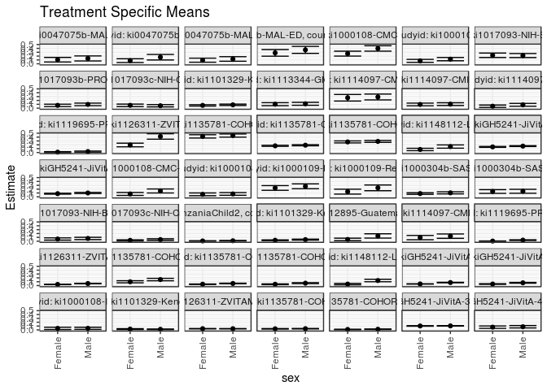

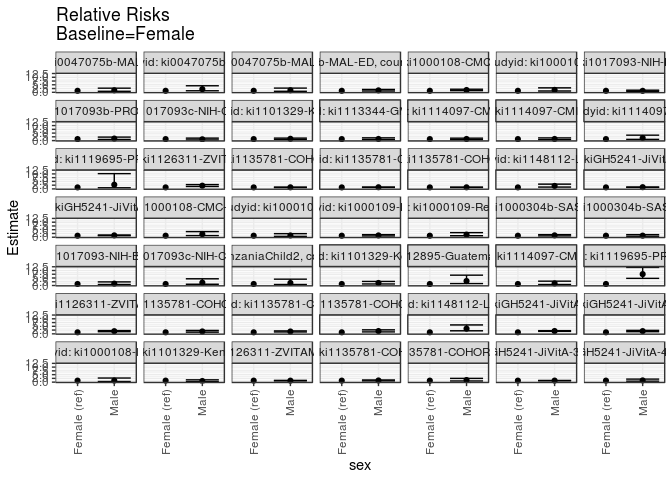

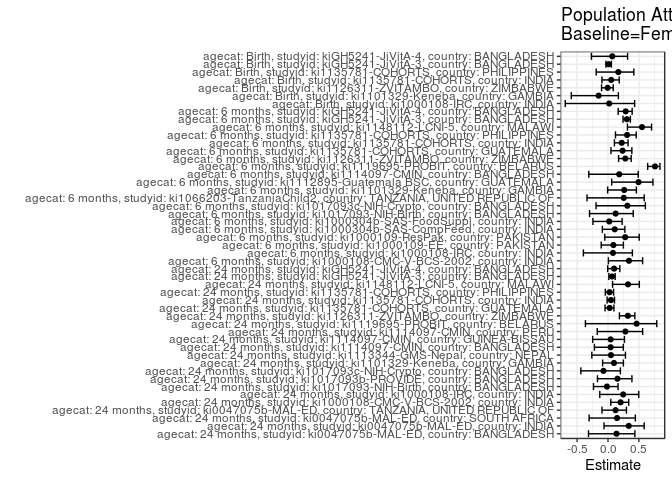

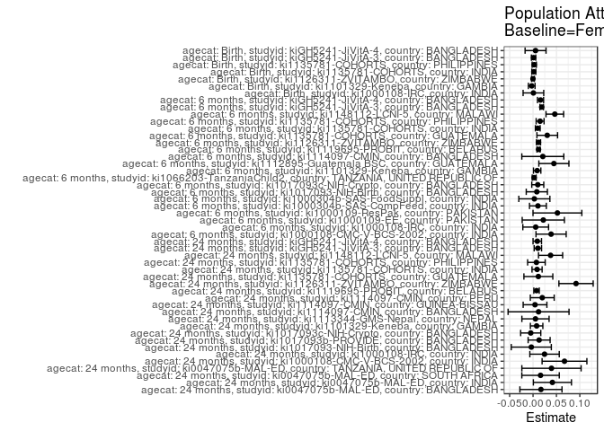

## Results Table

### Parameter: TSM

| agecat | studyid | country | intervention_level | baseline_level | estimate | ci_lower | ci_upper |
| --- | --- | --- | --- | --- | --- | --- | --- |
| Birth | ki1000108-IRC | INDIA | Female | NA | 0.0404624 | 0.0110628 | 0.0698621 |
| Birth | ki1000108-IRC | INDIA | Male | NA | 0.0418605 | 0.0150561 | 0.0686648 |
| Birth | ki1101329-Keneba | GAMBIA | Female | NA | 0.0216802 | 0.0111695 | 0.0321910 |
| Birth | ki1101329-Keneba | GAMBIA | Male | NA | 0.0161893 | 0.0074575 | 0.0249210 |
| Birth | ki1126311-ZVITAMBO | ZIMBABWE | Female | NA | 0.0320665 | 0.0278591 | 0.0362739 |
| Birth | ki1126311-ZVITAMBO | ZIMBABWE | Male | NA | 0.0317169 | 0.0276388 | 0.0357951 |
| Birth | ki1135781-COHORTS | INDIA | Female | NA | 0.0294210 | 0.0235611 | 0.0352809 |
| Birth | ki1135781-COHORTS | INDIA | Male | NA | 0.0325109 | 0.0265881 | 0.0384336 |
| Birth | ki1135781-COHORTS | PHILIPPINES | Female | NA | 0.0125611 | 0.0067939 | 0.0183283 |
| Birth | ki1135781-COHORTS | PHILIPPINES | Male | NA | 0.0173160 | 0.0109569 | 0.0236751 |
| Birth | kiGH5241-JiVitA-3 | BANGLADESH | Female | NA | 0.1029213 | 0.0964395 | 0.1094031 |
| Birth | kiGH5241-JiVitA-3 | BANGLADESH | Male | NA | 0.1051631 | 0.0986179 | 0.1117083 |
| Birth | kiGH5241-JiVitA-4 | BANGLADESH | Female | NA | 0.0725000 | 0.0413989 | 0.1036011 |
| Birth | kiGH5241-JiVitA-4 | BANGLADESH | Male | NA | 0.0829384 | 0.0521250 | 0.1137518 |
| 6 months | ki1000108-CMC-V-BCS-2002 | INDIA | Female | NA | 0.0752688 | 0.0373027 | 0.1132349 |
| 6 months | ki1000108-CMC-V-BCS-2002 | INDIA | Male | NA | 0.1530055 | 0.1007772 | 0.2052337 |
| 6 months | ki1000108-IRC | INDIA | Female | NA | 0.0655738 | 0.0296655 | 0.1014820 |
| 6 months | ki1000108-IRC | INDIA | Male | NA | 0.0758929 | 0.0411696 | 0.1106161 |
| 6 months | ki1000109-EE | PAKISTAN | Female | NA | 0.2307692 | 0.1694758 | 0.2920627 |
| 6 months | ki1000109-EE | PAKISTAN | Male | NA | 0.2736842 | 0.2102033 | 0.3371652 |
| 6 months | ki1000109-ResPak | PAKISTAN | Female | NA | 0.1351351 | 0.0714012 | 0.1988691 |
| 6 months | ki1000109-ResPak | PAKISTAN | Male | NA | 0.2338710 | 0.1592085 | 0.3085334 |
| 6 months | ki1000304b-SAS-CompFeed | INDIA | Female | NA | 0.0853859 | 0.0651040 | 0.1056678 |
| 6 months | ki1000304b-SAS-CompFeed | INDIA | Male | NA | 0.1045392 | 0.0770585 | 0.1320199 |
| 6 months | ki1000304b-SAS-FoodSuppl | INDIA | Female | NA | 0.1393035 | 0.0913712 | 0.1872358 |
| 6 months | ki1000304b-SAS-FoodSuppl | INDIA | Male | NA | 0.1452514 | 0.0935654 | 0.1969374 |
| 6 months | ki1017093-NIH-Birth | BANGLADESH | Female | NA | 0.0571429 | 0.0280508 | 0.0862349 |
| 6 months | ki1017093-NIH-Birth | BANGLADESH | Male | NA | 0.0719178 | 0.0422577 | 0.1015779 |
| 6 months | ki1017093c-NIH-Crypto | BANGLADESH | Female | NA | 0.0220994 | 0.0069452 | 0.0372537 |
| 6 months | ki1017093c-NIH-Crypto | BANGLADESH | Male | NA | 0.0424929 | 0.0214360 | 0.0635498 |

[output cut: 68 more lines]

### Parameter: E(Y)

| agecat | studyid | country | intervention_level | baseline_level | estimate | ci_lower | ci_upper |
| --- | --- | --- | --- | --- | --- | --- | --- |
| Birth | ki1000108-IRC | INDIA | NA | NA | 0.0412371 | 0.0214268 | 0.0610475 |
| Birth | ki1101329-Keneba | GAMBIA | NA | NA | 0.0188189 | 0.0120322 | 0.0256057 |
| Birth | ki1126311-ZVITAMBO | ZIMBABWE | NA | NA | 0.0318872 | 0.0289588 | 0.0348156 |
| Birth | ki1135781-COHORTS | INDIA | NA | NA | 0.0310241 | 0.0268535 | 0.0351947 |
| Birth | ki1135781-COHORTS | PHILIPPINES | NA | NA | 0.0150820 | 0.0107558 | 0.0194081 |
| Birth | kiGH5241-JiVitA-3 | BANGLADESH | NA | NA | 0.1040636 | 0.0993965 | 0.1087307 |
| Birth | kiGH5241-JiVitA-4 | BANGLADESH | NA | NA | 0.0778589 | 0.0559066 | 0.0998111 |
| 6 months | ki1000108-CMC-V-BCS-2002 | INDIA | NA | NA | 0.1138211 | 0.0813725 | 0.1462698 |
| 6 months | ki1000108-IRC | INDIA | NA | NA | 0.0712531 | 0.0462303 | 0.0962759 |
| 6 months | ki1000109-EE | PAKISTAN | NA | NA | 0.2526882 | 0.2084696 | 0.2969067 |
| 6 months | ki1000109-ResPak | PAKISTAN | NA | NA | 0.1872340 | 0.1372518 | 0.2372162 |
| 6 months | ki1000304b-SAS-CompFeed | INDIA | NA | NA | 0.0958084 | 0.0774939 | 0.1141229 |
| 6 months | ki1000304b-SAS-FoodSuppl | INDIA | NA | NA | 0.1421053 | 0.1069532 | 0.1772573 |
| 6 months | ki1017093-NIH-Birth | BANGLADESH | NA | NA | 0.0651769 | 0.0442802 | 0.0860736 |
| 6 months | ki1017093c-NIH-Crypto | BANGLADESH | NA | NA | 0.0321678 | 0.0192256 | 0.0451101 |
| 6 months | ki1066203-TanzaniaChild2 | TANZANIA, UNITED REPUBLIC OF | NA | NA | 0.0093642 | 0.0051724 | 0.0135561 |
| 6 months | ki1101329-Keneba | GAMBIA | NA | NA | 0.0335089 | 0.0257898 | 0.0412279 |
| 6 months | ki1112895-Guatemala BSC | GUATEMALA | NA | NA | 0.0903010 | 0.0577597 | 0.1228423 |
| 6 months | ki1114097-CMIN | BANGLADESH | NA | NA | 0.1152263 | 0.0749980 | 0.1554547 |
| 6 months | ki1119695-PROBIT | BELARUS | NA | NA | 0.0154178 | 0.0100323 | 0.0208033 |
| 6 months | ki1126311-ZVITAMBO | ZIMBABWE | NA | NA | 0.0417119 | 0.0374091 | 0.0460146 |
| 6 months | ki1135781-COHORTS | GUATEMALA | NA | NA | 0.1290323 | 0.1078261 | 0.1502384 |
| 6 months | ki1135781-COHORTS | INDIA | NA | NA | 0.0453353 | 0.0404119 | 0.0502586 |
| 6 months | ki1135781-COHORTS | PHILIPPINES | NA | NA | 0.0487445 | 0.0406327 | 0.0568562 |
| 6 months | ki1148112-LCNI-5 | MALAWI | NA | NA | 0.0846246 | 0.0657805 | 0.1034686 |
| 6 months | kiGH5241-JiVitA-3 | BANGLADESH | NA | NA | 0.0606746 | 0.0568229 | 0.0645262 |
| 6 months | kiGH5241-JiVitA-4 | BANGLADESH | NA | NA | 0.0558890 | 0.0491390 | 0.0626391 |
| 24 months | ki0047075b-MAL-ED | BANGLADESH | NA | NA | 0.1226415 | 0.0783812 | 0.1669018 |
| 24 months | ki0047075b-MAL-ED | INDIA | NA | NA | 0.1233480 | 0.0804760 | 0.1662200 |
| 24 months | ki0047075b-MAL-ED | SOUTH AFRICA | NA | NA | 0.1092437 | 0.0695290 | 0.1489584 |
| 24 months | ki0047075b-MAL-ED | TANZANIA, UNITED REPUBLIC OF | NA | NA | 0.3224299 | 0.2596598 | 0.3852000 |
| 24 months | ki1000108-CMC-V-BCS-2002 | INDIA | NA | NA | 0.3306452 | 0.2827744 | 0.3785159 |
| 24 months | ki1000108-IRC | INDIA | NA | NA | 0.1002445 | 0.0711031 | 0.1293859 |
| 24 months | ki1017093-NIH-Birth | BANGLADESH | NA | NA | 0.2167832 | 0.1777459 | 0.2558205 |
| 24 months | ki1017093b-PROVIDE | BANGLADESH | NA | NA | 0.0849220 | 0.0621566 | 0.1076874 |
| 24 months | ki1017093c-NIH-Crypto | BANGLADESH | NA | NA | 0.0680934 | 0.0462948 | 0.0898920 |
| 24 months | ki1101329-Keneba | GAMBIA | NA | NA | 0.0794203 | 0.0666566 | 0.0921840 |
| 24 months | ki1113344-GMS-Nepal | NEPAL | NA | NA | 0.1082164 | 0.0809323 | 0.1355005 |
| 24 months | ki1114097-CMIN | BANGLADESH | NA | NA | 0.2809917 | 0.2242434 | 0.3377401 |
| 24 months | ki1114097-CMIN | GUINEA-BISSAU | NA | NA | 0.0998185 | 0.0747668 | 0.1248702 |
| 24 months | ki1114097-CMIN | PERU | NA | NA | 0.0699301 | 0.0457690 | 0.0940911 |
| 24 months | ki1119695-PROBIT | BELARUS | NA | NA | 0.0161090 | 0.0034156 | 0.0288025 |
| 24 months | ki1126311-ZVITAMBO | ZIMBABWE | NA | NA | 0.2866521 | 0.2451477 | 0.3281565 |
| 24 months | ki1135781-COHORTS | GUATEMALA | NA | NA | 0.4296365 | 0.4000034 | 0.4592696 |
| 24 months | ki1135781-COHORTS | INDIA | NA | NA | 0.1814607 | 0.1711228 | 0.1917985 |
| 24 months | ki1135781-COHORTS | PHILIPPINES | NA | NA | 0.2817996 | 0.2639639 | 0.2996353 |
| 24 months | ki1148112-LCNI-5 | MALAWI | NA | NA | 0.1157168 | 0.0896385 | 0.1417950 |
| 24 months | kiGH5241-JiVitA-3 | BANGLADESH | NA | NA | 0.1559314 | 0.1471744 | 0.1646884 |
| 24 months | kiGH5241-JiVitA-4 | BANGLADESH | NA | NA | 0.0919613 | 0.0825825 | 0.1013401 |

### Parameter: RR

| agecat | studyid | country | intervention_level | baseline_level | estimate | ci_lower | ci_upper |
| --- | --- | --- | --- | --- | --- | --- | --- |
| Birth | ki1000108-IRC | INDIA | Female | Female | 1.0000000 | 1.0000000 | 1.000000 |
| Birth | ki1000108-IRC | INDIA | Male | Female | 1.0345515 | 0.3927774 | 2.724945 |
| Birth | ki1101329-Keneba | GAMBIA | Female | Female | 1.0000000 | 1.0000000 | 1.000000 |
| Birth | ki1101329-Keneba | GAMBIA | Male | Female | 0.7467310 | 0.3615816 | 1.542134 |
| Birth | ki1126311-ZVITAMBO | ZIMBABWE | Female | Female | 1.0000000 | 1.0000000 | 1.000000 |
| Birth | ki1126311-ZVITAMBO | ZIMBABWE | Male | Female | 0.9890988 | 0.8231077 | 1.188564 |
| Birth | ki1135781-COHORTS | INDIA | Female | Female | 1.0000000 | 1.0000000 | 1.000000 |
| Birth | ki1135781-COHORTS | INDIA | Male | Female | 1.1050242 | 0.8436171 | 1.447432 |
| Birth | ki1135781-COHORTS | PHILIPPINES | Female | Female | 1.0000000 | 1.0000000 | 1.000000 |
| Birth | ki1135781-COHORTS | PHILIPPINES | Male | Female | 1.3785474 | 0.7657469 | 2.481751 |
| Birth | kiGH5241-JiVitA-3 | BANGLADESH | Female | Female | 1.0000000 | 1.0000000 | 1.000000 |
| Birth | kiGH5241-JiVitA-3 | BANGLADESH | Male | Female | 1.0217817 | 0.9362844 | 1.115086 |
| Birth | kiGH5241-JiVitA-4 | BANGLADESH | Female | Female | 1.0000000 | 1.0000000 | 1.000000 |
| Birth | kiGH5241-JiVitA-4 | BANGLADESH | Male | Female | 1.1439778 | 0.6499795 | 2.013425 |
| 6 months | ki1000108-CMC-V-BCS-2002 | INDIA | Female | Female | 1.0000000 | 1.0000000 | 1.000000 |
| 6 months | ki1000108-CMC-V-BCS-2002 | INDIA | Male | Female | 2.0327869 | 1.1055630 | 3.737664 |
| 6 months | ki1000108-IRC | INDIA | Female | Female | 1.0000000 | 1.0000000 | 1.000000 |
| 6 months | ki1000108-IRC | INDIA | Male | Female | 1.1573661 | 0.5669775 | 2.362521 |
| 6 months | ki1000109-EE | PAKISTAN | Female | Female | 1.0000000 | 1.0000000 | 1.000000 |
| 6 months | ki1000109-EE | PAKISTAN | Male | Female | 1.1859649 | 0.8335417 | 1.687393 |
| 6 months | ki1000109-ResPak | PAKISTAN | Female | Female | 1.0000000 | 1.0000000 | 1.000000 |
| 6 months | ki1000109-ResPak | PAKISTAN | Male | Female | 1.7306452 | 0.9791926 | 3.058778 |
| 6 months | ki1000304b-SAS-CompFeed | INDIA | Female | Female | 1.0000000 | 1.0000000 | 1.000000 |
| 6 months | ki1000304b-SAS-CompFeed | INDIA | Male | Female | 1.2243149 | 0.8718166 | 1.719337 |
| 6 months | ki1000304b-SAS-FoodSuppl | INDIA | Female | Female | 1.0000000 | 1.0000000 | 1.000000 |
| 6 months | ki1000304b-SAS-FoodSuppl | INDIA | Male | Female | 1.0426975 | 0.6356040 | 1.710527 |
| 6 months | ki1017093-NIH-Birth | BANGLADESH | Female | Female | 1.0000000 | 1.0000000 | 1.000000 |
| 6 months | ki1017093-NIH-Birth | BANGLADESH | Male | Female | 1.2585616 | 0.6536222 | 2.423384 |
| 6 months | ki1017093c-NIH-Crypto | BANGLADESH | Female | Female | 1.0000000 | 1.0000000 | 1.000000 |
| 6 months | ki1017093c-NIH-Crypto | BANGLADESH | Male | Female | 1.9228045 | 0.8250949 | 4.480912 |

[output cut: 68 more lines]

### Parameter: PAR

| agecat | studyid | country | intervention_level | baseline_level | estimate | ci_lower | ci_upper |
| --- | --- | --- | --- | --- | --- | --- | --- |
| Birth | ki1000108-IRC | INDIA | Female | NA | 0.0007747 | -0.0212710 | 0.0228204 |
| Birth | ki1101329-Keneba | GAMBIA | Female | NA | -0.0028613 | -0.0099830 | 0.0042605 |
| Birth | ki1126311-ZVITAMBO | ZIMBABWE | Female | NA | -0.0001793 | -0.0031849 | 0.0028263 |
| Birth | ki1135781-COHORTS | INDIA | Female | NA | 0.0016031 | -0.0027197 | 0.0059260 |
| Birth | ki1135781-COHORTS | PHILIPPINES | Female | NA | 0.0025209 | -0.0020312 | 0.0070730 |
| Birth | kiGH5241-JiVitA-3 | BANGLADESH | Female | NA | 0.0011423 | -0.0034897 | 0.0057744 |
| Birth | kiGH5241-JiVitA-4 | BANGLADESH | Female | NA | 0.0053589 | -0.0170384 | 0.0277561 |
| 6 months | ki1000108-CMC-V-BCS-2002 | INDIA | Female | NA | 0.0385523 | 0.0062848 | 0.0708199 |
| 6 months | ki1000108-IRC | INDIA | Female | NA | 0.0056793 | -0.0218167 | 0.0331753 |
| 6 months | ki1000109-EE | PAKISTAN | Female | NA | 0.0219189 | -0.0232039 | 0.0670418 |
| 6 months | ki1000109-ResPak | PAKISTAN | Female | NA | 0.0520989 | -0.0000828 | 0.1042806 |
| 6 months | ki1000304b-SAS-CompFeed | INDIA | Female | NA | 0.0104225 | -0.0075697 | 0.0284147 |
| 6 months | ki1000304b-SAS-FoodSuppl | INDIA | Female | NA | 0.0028018 | -0.0304044 | 0.0360080 |
| 6 months | ki1017093-NIH-Birth | BANGLADESH | Female | NA | 0.0080341 | -0.0145656 | 0.0306337 |
| 6 months | ki1017093c-NIH-Crypto | BANGLADESH | Female | NA | 0.0100684 | -0.0027617 | 0.0228985 |
| 6 months | ki1066203-TanzaniaChild2 | TANZANIA, UNITED REPUBLIC OF | Female | NA | 0.0023852 | -0.0018425 | 0.0066128 |
| 6 months | ki1101329-Keneba | GAMBIA | Female | NA | 0.0087809 | 0.0008737 | 0.0166880 |
| 6 months | ki1112895-Guatemala BSC | GUATEMALA | Female | NA | 0.0445494 | 0.0124061 | 0.0766926 |
| 6 months | ki1114097-CMIN | BANGLADESH | Female | NA | 0.0208867 | -0.0240016 | 0.0657750 |
| 6 months | ki1119695-PROBIT | BELARUS | Female | NA | 0.0117332 | 0.0082841 | 0.0151823 |
| 6 months | ki1126311-ZVITAMBO | ZIMBABWE | Female | NA | 0.0116945 | 0.0073021 | 0.0160869 |
| 6 months | ki1135781-COHORTS | GUATEMALA | Female | NA | 0.0303480 | 0.0082585 | 0.0524376 |
| 6 months | ki1135781-COHORTS | INDIA | Female | NA | 0.0100447 | 0.0049557 | 0.0151338 |
| 6 months | ki1135781-COHORTS | PHILIPPINES | Female | NA | 0.0150454 | 0.0065926 | 0.0234982 |
| 6 months | ki1148112-LCNI-5 | MALAWI | Female | NA | 0.0465293 | 0.0276959 | 0.0653627 |
| 6 months | kiGH5241-JiVitA-3 | BANGLADESH | Female | NA | 0.0184876 | 0.0147219 | 0.0222534 |
| 6 months | kiGH5241-JiVitA-4 | BANGLADESH | Female | NA | 0.0160054 | 0.0094819 | 0.0225288 |
| 24 months | ki0047075b-MAL-ED | BANGLADESH | Female | NA | 0.0168723 | -0.0281300 | 0.0618745 |
| 24 months | ki0047075b-MAL-ED | INDIA | Female | NA | 0.0413808 | 0.0006404 | 0.0821212 |
| 24 months | ki0047075b-MAL-ED | SOUTH AFRICA | Female | NA | 0.0160234 | -0.0239827 | 0.0560294 |
| 24 months | ki0047075b-MAL-ED | TANZANIA, UNITED REPUBLIC OF | Female | NA | 0.0394110 | -0.0239067 | 0.1027288 |
| 24 months | ki1000108-CMC-V-BCS-2002 | INDIA | Female | NA | 0.0672043 | 0.0193335 | 0.1150751 |
| 24 months | ki1000108-IRC | INDIA | Female | NA | 0.0245688 | -0.0068646 | 0.0560022 |
| 24 months | ki1017093-NIH-Birth | BANGLADESH | Female | NA | -0.0037296 | -0.0465369 | 0.0390777 |
| 24 months | ki1017093b-PROVIDE | BANGLADESH | Female | NA | 0.0129796 | -0.0105130 | 0.0364721 |
| 24 months | ki1017093c-NIH-Crypto | BANGLADESH | Female | NA | -0.0049835 | -0.0265120 | 0.0165449 |
| 24 months | ki1101329-Keneba | GAMBIA | Female | NA | 0.0076441 | -0.0056803 | 0.0209686 |
| 24 months | ki1113344-GMS-Nepal | NEPAL | Female | NA | 0.0052121 | -0.0238630 | 0.0342873 |
| 24 months | ki1114097-CMIN | BANGLADESH | Female | NA | 0.0117610 | -0.0533975 | 0.0769194 |
| 24 months | ki1114097-CMIN | GUINEA-BISSAU | Female | NA | 0.0042303 | -0.0211297 | 0.0295902 |
| 24 months | ki1114097-CMIN | PERU | Female | NA | 0.0196788 | -0.0058258 | 0.0451834 |
| 24 months | ki1119695-PROBIT | BELARUS | Female | NA | 0.0074594 | 0.0016507 | 0.0132680 |
| 24 months | ki1126311-ZVITAMBO | ZIMBABWE | Female | NA | 0.0918955 | 0.0552675 | 0.1285235 |
| 24 months | ki1135781-COHORTS | GUATEMALA | Female | NA | 0.0113486 | -0.0195457 | 0.0422429 |
| 24 months | ki1135781-COHORTS | INDIA | Female | NA | 0.0085727 | -0.0022430 | 0.0193883 |
| 24 months | ki1135781-COHORTS | PHILIPPINES | Female | NA | 0.0071882 | -0.0115999 | 0.0259763 |
| 24 months | ki1148112-LCNI-5 | MALAWI | Female | NA | 0.0374855 | 0.0116901 | 0.0632809 |
| 24 months | kiGH5241-JiVitA-3 | BANGLADESH | Female | NA | 0.0102980 | 0.0023770 | 0.0182191 |
| 24 months | kiGH5241-JiVitA-4 | BANGLADESH | Female | NA | 0.0090488 | -0.0000013 | 0.0180990 |

### Parameter: PAF

| agecat | studyid | country | intervention_level | baseline_level | estimate | ci_lower | ci_upper |
| --- | --- | --- | --- | --- | --- | --- | --- |
| Birth | ki1000108-IRC | INDIA | Female | NA | 0.0187861 | -0.6918250 | 0.4309218 |
| Birth | ki1101329-Keneba | GAMBIA | Female | NA | -0.1520419 | -0.5947466 | 0.1677672 |
| Birth | ki1126311-ZVITAMBO | ZIMBABWE | Female | NA | -0.0056232 | -0.1044369 | 0.0843497 |
| Birth | ki1135781-COHORTS | INDIA | Female | NA | 0.0516736 | -0.0982336 | 0.1811187 |
| Birth | ki1135781-COHORTS | PHILIPPINES | Female | NA | 0.1671471 | -0.1912679 | 0.4177263 |
| Birth | kiGH5241-JiVitA-3 | BANGLADESH | Female | NA | 0.0109772 | -0.0345395 | 0.0544914 |
| Birth | kiGH5241-JiVitA-4 | BANGLADESH | Female | NA | 0.0688281 | -0.2686768 | 0.3165469 |
| 6 months | ki1000108-CMC-V-BCS-2002 | INDIA | Female | NA | 0.3387097 | 0.0060127 | 0.5600498 |
| 6 months | ki1000108-IRC | INDIA | Female | NA | 0.0797060 | -0.3983647 | 0.3943347 |
| 6 months | ki1000109-EE | PAKISTAN | Female | NA | 0.0867430 | -0.1101822 | 0.2487375 |
| 6 months | ki1000109-ResPak | PAKISTAN | Female | NA | 0.2782555 | -0.0521068 | 0.5048838 |
| 6 months | ki1000304b-SAS-CompFeed | INDIA | Female | NA | 0.1087849 | -0.0919101 | 0.2725918 |
| 6 months | ki1000304b-SAS-FoodSuppl | INDIA | Female | NA | 0.0197162 | -0.2441156 | 0.2275989 |
| 6 months | ki1017093-NIH-Birth | BANGLADESH | Female | NA | 0.1232653 | -0.2991140 | 0.4083170 |
| 6 months | ki1017093c-NIH-Crypto | BANGLADESH | Female | NA | 0.3129954 | -0.1934420 | 0.6045260 |
| 6 months | ki1066203-TanzaniaChild2 | TANZANIA, UNITED REPUBLIC OF | Female | NA | 0.2547095 | -0.3396652 | 0.5853756 |
| 6 months | ki1101329-Keneba | GAMBIA | Female | NA | 0.2620461 | -0.0058231 | 0.4585768 |
| 6 months | ki1112895-Guatemala BSC | GUATEMALA | Female | NA | 0.4933430 | 0.0593408 | 0.7271049 |
| 6 months | ki1114097-CMIN | BANGLADESH | Female | NA | 0.1812668 | -0.3110833 | 0.4887251 |
| 6 months | ki1119695-PROBIT | BELARUS | Female | NA | 0.7610166 | 0.6415262 | 0.8406772 |
| 6 months | ki1126311-ZVITAMBO | ZIMBABWE | Female | NA | 0.2803640 | 0.1713436 | 0.3750414 |
| 6 months | ki1135781-COHORTS | GUATEMALA | Female | NA | 0.2351974 | 0.0475846 | 0.3858530 |
| 6 months | ki1135781-COHORTS | INDIA | Female | NA | 0.2215656 | 0.1035989 | 0.3240078 |
| 6 months | ki1135781-COHORTS | PHILIPPINES | Female | NA | 0.3086587 | 0.1207890 | 0.4563844 |
| 6 months | ki1148112-LCNI-5 | MALAWI | Female | NA | 0.5498323 | 0.3147039 | 0.7042870 |
| 6 months | kiGH5241-JiVitA-3 | BANGLADESH | Female | NA | 0.3047014 | 0.2428077 | 0.3615359 |
| 6 months | kiGH5241-JiVitA-4 | BANGLADESH | Female | NA | 0.2863777 | 0.1642881 | 0.3906311 |
| 24 months | ki0047075b-MAL-ED | BANGLADESH | Female | NA | 0.1375740 | -0.3158776 | 0.4347661 |
| 24 months | ki0047075b-MAL-ED | INDIA | Female | NA | 0.3354801 | -0.0644825 | 0.5851630 |
| 24 months | ki0047075b-MAL-ED | SOUTH AFRICA | Female | NA | 0.1466753 | -0.3059463 | 0.4424250 |
| 24 months | ki0047075b-MAL-ED | TANZANIA, UNITED REPUBLIC OF | Female | NA | 0.1222313 | -0.0975496 | 0.2980018 |
| 24 months | ki1000108-CMC-V-BCS-2002 | INDIA | Female | NA | 0.2032520 | 0.0452483 | 0.3351074 |
| 24 months | ki1000108-IRC | INDIA | Female | NA | 0.2450890 | -0.1333731 | 0.4971730 |
| 24 months | ki1017093-NIH-Birth | BANGLADESH | Female | NA | -0.0172043 | -0.2351267 | 0.1622684 |
| 24 months | ki1017093b-PROVIDE | BANGLADESH | Female | NA | 0.1528410 | -0.1707534 | 0.3869944 |
| 24 months | ki1017093c-NIH-Crypto | BANGLADESH | Female | NA | -0.0731868 | -0.4398645 | 0.2001123 |
| 24 months | ki1101329-Keneba | GAMBIA | Female | NA | 0.0962491 | -0.0873786 | 0.2488673 |
| 24 months | ki1113344-GMS-Nepal | NEPAL | Female | NA | 0.0481640 | -0.2619862 | 0.2820907 |
| 24 months | ki1114097-CMIN | BANGLADESH | Female | NA | 0.0418552 | -0.2204509 | 0.2477850 |
| 24 months | ki1114097-CMIN | GUINEA-BISSAU | Female | NA | 0.0423797 | -0.2483430 | 0.2653969 |
| 24 months | ki1114097-CMIN | PERU | Female | NA | 0.2814070 | -0.1743712 | 0.5602959 |
| 24 months | ki1119695-PROBIT | BELARUS | Female | NA | 0.4630540 | -0.3655942 | 0.7888751 |
| 24 months | ki1126311-ZVITAMBO | ZIMBABWE | Female | NA | 0.3205821 | 0.1846750 | 0.4338348 |
| 24 months | ki1135781-COHORTS | GUATEMALA | Female | NA | 0.0264144 | -0.0482273 | 0.0957411 |
| 24 months | ki1135781-COHORTS | INDIA | Female | NA | 0.0472425 | -0.0142270 | 0.1049865 |
| 24 months | ki1135781-COHORTS | PHILIPPINES | Female | NA | 0.0255082 | -0.0434923 | 0.0899460 |
| 24 months | ki1148112-LCNI-5 | MALAWI | Female | NA | 0.3239415 | 0.0737703 | 0.5065424 |
| 24 months | kiGH5241-JiVitA-3 | BANGLADESH | Female | NA | 0.0660420 | 0.0137490 | 0.1155623 |
| 24 months | kiGH5241-JiVitA-4 | BANGLADESH | Female | NA | 0.0983982 | -0.0051545 | 0.1912827 |